# What factors affect the income of Mexican immigrants in U.S.

# 4 Task 4: Code Book

```r
attach(income)
```

[output not shown]

```r
detach(income)
```

# 5 Task 5: The Subjects

The resulted data set describe the income and other relavant variables of 643 Mexcian immigrants, who live in America and participated in 1994 United States census questionnaires.

# 6 Task 6: The Variables

There are 10 variables in the `income` data set.

# 7 Task 7: Linear Model Plans

In this project, I will predict the quantitative outcome **capital_net_gain** using some combination of the following 7 variables:

- `age`
- `workclass`
- `fnlwgt`
- `education_num`
- `race`
- `sex`
- `hours_per_week`

In advance, I might anticipate that all these predictors may impact the `capital_net_gain`. But better insights will be gained after the analysis.

## 7.1 Spearman $\rho^2$ Plot

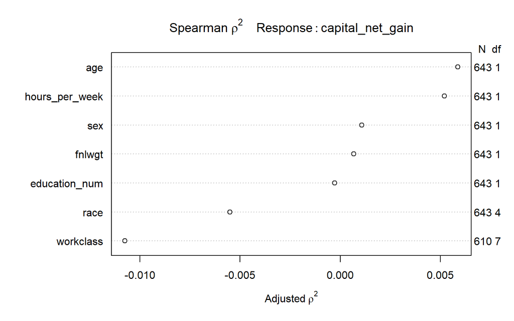

```r
plot(spearman2(capital_net_gain ~ age + workclass + fnlwgt + education_num + race + sex + hours_per_week, data = income))
```

# 8 Task 8: Logistic Model Plans

I will predict the binary outcome **income** using some combination of the same 7 variables as in linear model:

- `age`
- `workclass`
- `fnlwgt`
- `education_num`
- `race`
- `sex`
- `hours_per_week`

In advance, I might anticipate that all these predictors may impact the `income`. But better insights will be gained after the analysis.

## 8.1 Spearman $\rho^2$ Plot

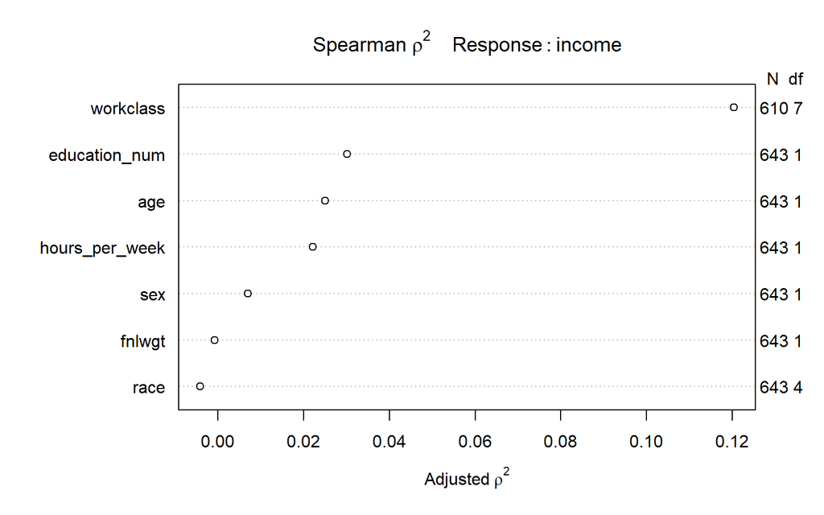

```r
plot(spearman2(income ~ age + workclass + fnlwgt + education_num + race + sex + hours_per_week, data = income))
```

# 9 Task 9: Affirmation

This data set meets all requirements specified in the project instructions.

Shufen_Cao

2018-03-07 23:32:59